# Text Analyis

## More Sentimental & Quantitative Analysis

### Q1. Which is the most common word pairs (ngrams) in harry potter series

```r
harrypotterSeries_ngrams <- harrypotterSeries %>%
  unnest_tokens(bigram, sentence, token = "ngrams", n = 2) %>%
  separate(bigram, c("word1", "word2"), sep = " ") %>%
  filter(!word1 %in% stop_words$word) %>%
  filter(!word2 %in% stop_words$word)

bigram_counts <- harrypotterSeries_ngrams %>%
  count(word1, word2, sort = TRUE)

head(bigram_counts)
```

```
## # A tibble: 6 x 3
##       word1      word2     n
##       <chr>      <chr> <int>
## 1 professor mcgonagall   581
## 2     uncle     vernon   387
## 3     death     eaters   346
## 4     harry     potter   346
## 5     harry     looked   322
## 6     harry        ron   276
```

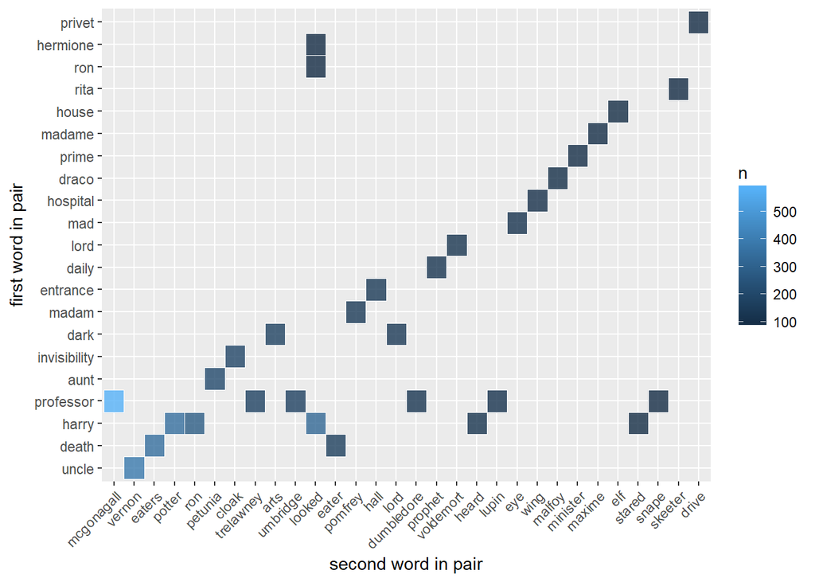

```r
bigram_counts%>%
  filter(n > 80)%>%
  ggplot(aes(x = reorder(word1, -n), y = reorder(word2, -n), fill = n)) +
  geom_tile(alpha = 0.8, color = "white") +
  coord_flip() +
  theme(legend.position = "right") +
  theme(axis.text.x = element_text(angle = 45, vjust = 1, hjust = 1)) +
  labs(x = "first word in pair",
       y = "second word in pair")
```

### Q2. Analyze the network structure of the word pairs (ngrams) in harry potter series

[figure not shown]

```r
bigram_graph <- bigram_counts %>%
  filter(n > 60) %>%
  graph_from_data_frame()
# set seed
set.seed(2017)
# define arrow
a <- grid::arrow(type = "closed", length = unit(.10, "inches"))
# generate graph
ggraph(bigram_graph, layout = "fr") +
  geom_edge_link(aes(edge_alpha = n), show.legend = FALSE,
                 arrow = a, end_cap = circle(.07, 'inches')) +
  geom_node_point(color = "chartreuse", size = 5) +
  geom_node_text(aes(label = name), vjust = 1, hjust = 1) +
  theme_void()
```

### Q3. Examine how often sentiment-associated words are preceded by “not” or other negating words.

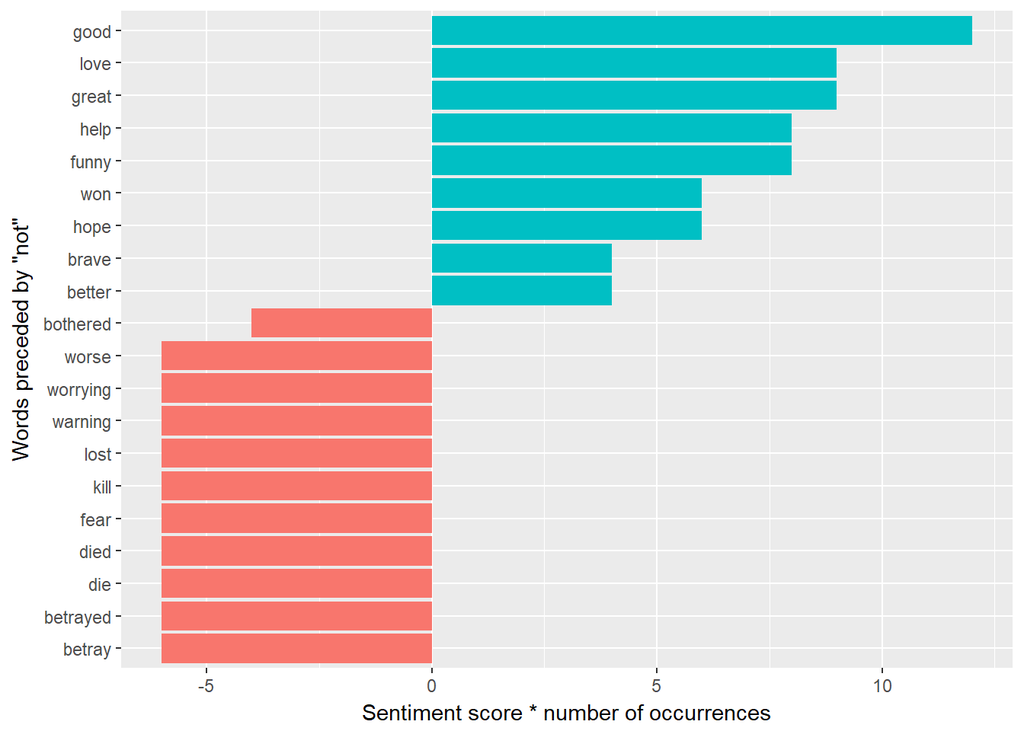

```r
# create hp_big_grams object
hp_bigrams_separated  <- harrypotterSeries %>%
  unnest_tokens(bigram, sentence, token = "ngrams", n = 2) %>%
  separate(bigram, c("word1", "word2"), sep = " ") %>%
  count(word1, word2, sort = TRUE)

negative_words <- c("not", "no", "never", "without")

hp_negated_words  <- hp_bigrams_separated %>%
  # filter by negative words
  filter(word1 %in% negative_words) %>%
  inner_join(get_sentiments("afinn"), by = c(word2 = "word")) %>%
  count(word2, score, sort = TRUE) %>%
  ungroup()


hp_negated_words %>%
  mutate(contribution = nn * score) %>%
  arrange(desc(abs(contribution))) %>%
  head(20) %>%
  mutate(word2 = reorder(word2, contribution)) %>%
  ggplot(aes(word2, nn * score, fill = nn * score > 0)) +
  geom_col(show.legend = FALSE) +
  xlab("Words preceded by \"not\"") +
  ylab("Sentiment score * number of occurrences") +
  coord_flip()
```

### Q4.What is the frequency distribution of words for each Harry Potter Book

```r
book_words <- harrypotter_clean_tokens %>%
  count(Title, word, sort = TRUE) %>%
  ungroup()

total_words <- book_words %>%
  group_by(Title) %>%
  summarize(total = sum(n))

book_words <- left_join(book_words, total_words)

head(book_words)
```

```
## # A tibble: 6 x 4
##                                       Title  word     n total
##                                       <chr> <chr> <int> <int>
## 1 Harry Potter and the Order of the Phoenix harry  3732 96784
## 2       Harry Potter and the Goblet of Fire harry  2936 72663
## 3      Harry Potter and the Deathly Hallows harry  2892 73514
## 4    Harry Potter and the Half-blood Prince harry  2617 63130
## 5  Harry Potter and the Prisoner of Azkaban harry  1824 41188
## 6   Harry Potter and the Chamber of Secrets harry  1503 33621
```

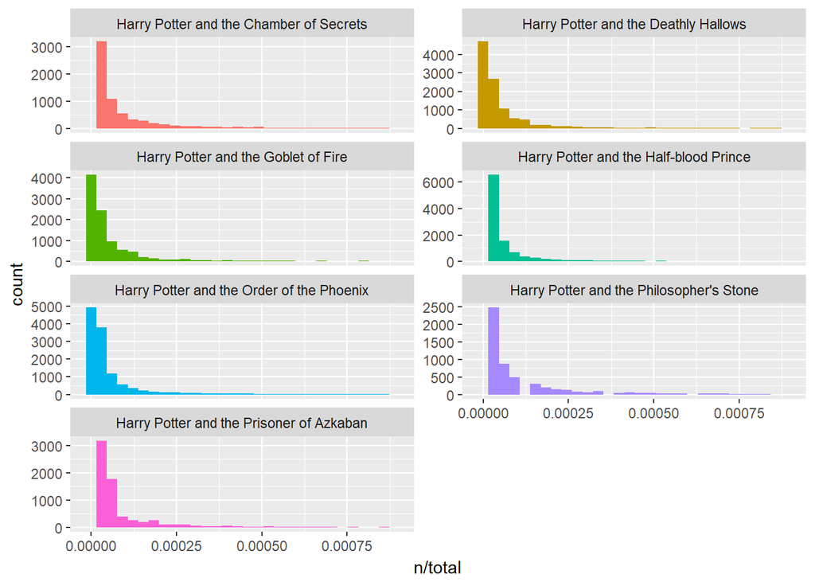

```r
ggplot(book_words, aes(n/total, fill = Title)) +
  geom_histogram(show.legend = FALSE) +
  xlim(NA, 0.0009) +
  facet_wrap(~Title, ncol = 2, scales = "free_y")
```

```r
# These plots exhibit similar distributions for all the books, with most of the words occuring rarely and fewer words that occur frequently.
```

### Q5. Does Zipf’s law holds for Harry Potter series?

```r
freq_by_rank <- book_words %>%
  group_by(Title) %>%
  mutate(rank = row_number(),
         `term frequency` = n/total)

head(freq_by_rank)
```

```
## # A tibble: 6 x 6
## # Groups:   Title [6]
##                                       Title  word     n total  rank
##                                       <chr> <chr> <int> <int> <int>
## 1 Harry Potter and the Order of the Phoenix harry  3732 96784     1
## 2       Harry Potter and the Goblet of Fire harry  2936 72663     1
## 3      Harry Potter and the Deathly Hallows harry  2892 73514     1
## 4    Harry Potter and the Half-blood Prince harry  2617 63130     1
## 5  Harry Potter and the Prisoner of Azkaban harry  1824 41188     1
## 6   Harry Potter and the Chamber of Secrets harry  1503 33621     1
## # ... with 1 more variables: `term frequency` <dbl>
```

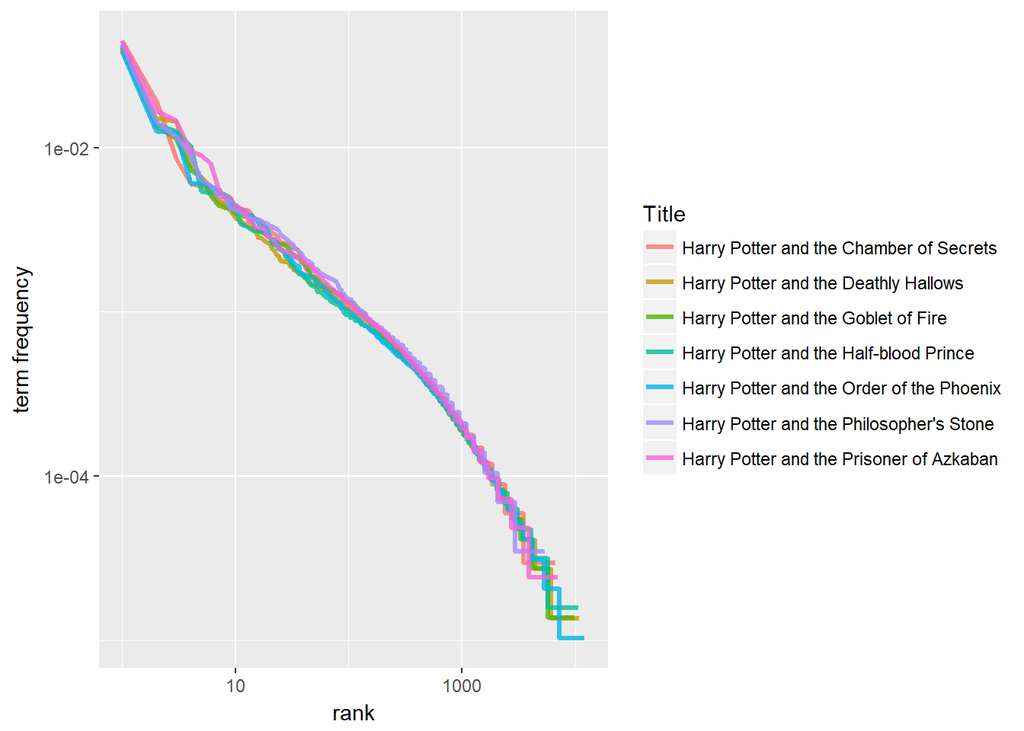

```r
freq_by_rank %>%
  ggplot(aes(rank, `term frequency`, color = Title)) +
  geom_line(size = 1.2, alpha = 0.8) +
  scale_x_log10() +
  scale_y_log10()
```

```r
# We see that all 7 novels are similar to each other, and that the relationship between rank and frequency does have negative slope.
```

### Q6. Does *power law* holds in Harry Potter series?

```r
rank_subset <- freq_by_rank %>%
  filter(rank < 500,
         rank > 10)

lm(log10(`term frequency`) ~ log10(rank), data = rank_subset)
```

```
##
## Call:
## lm(formula = log10(`term frequency`) ~ log10(rank), data = rank_subset)
##
## Coefficients:
## (Intercept)  log10(rank)
##     -1.7199      -0.6228
```

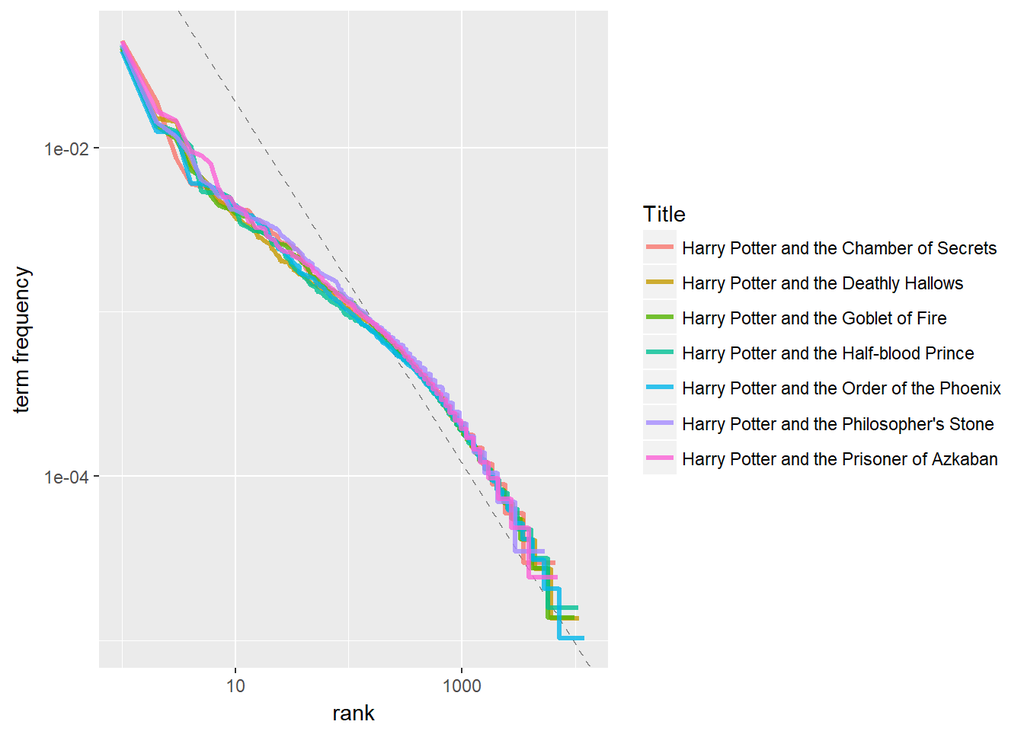

```r
freq_by_rank %>%
  ggplot(aes(rank, `term frequency`, color = Title)) +
  geom_abline(intercept = -0.62, slope = -1.1, color = "gray50", linetype = 2) +
  geom_line(size = 1.2, alpha = 0.8) +
  scale_x_log10() +
  scale_y_log10()
```

```r
# we can see that we have deviations at higher ranks.This is unusual, because the author uses  a lower percentage of the most common words
```

### Q7. How does positive sentiment change over time, Does the author has a specific pattern of control of positive sentiment?

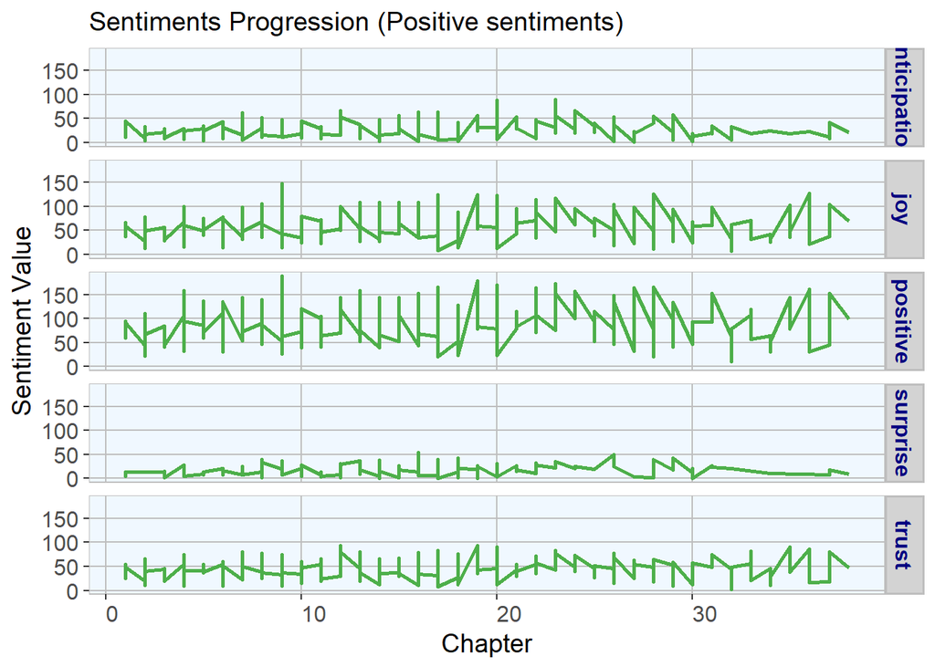

```r
# using nrc and afinn to get both sentiment and score
harrypotter_sentiment <- harrypotter_clean_tokens%>%
  inner_join(get_sentiments("nrc"), by = "word") %>%
  inner_join(get_sentiments("afinn"), by = "word") %>%
  group_by(Title, Chapter,sentiment)%>%
  summarise(count=sum(score))

harrypotter_sentiment%>%
  filter(count>0)%>%
  ggplot( aes(x = Chapter, y = count)) +
  geom_line(size = 1, color = brewer.pal(3, "Set1")[3]) +
  facet_grid(sentiment~.) +
  uniform_ggplot_theme() +
  theme(
    axis.text.x = element_text(angle = 0, vjust = 0, hjust = 0),
    legend.position = "none") +
  labs(x = "Chapter", y = "Sentiment Value",
       title = "Sentiments Progression (Positive sentiments)")
```

### Q8. How does negative sentiments changes over time? Is there any similarities in the 1st and last chapter?

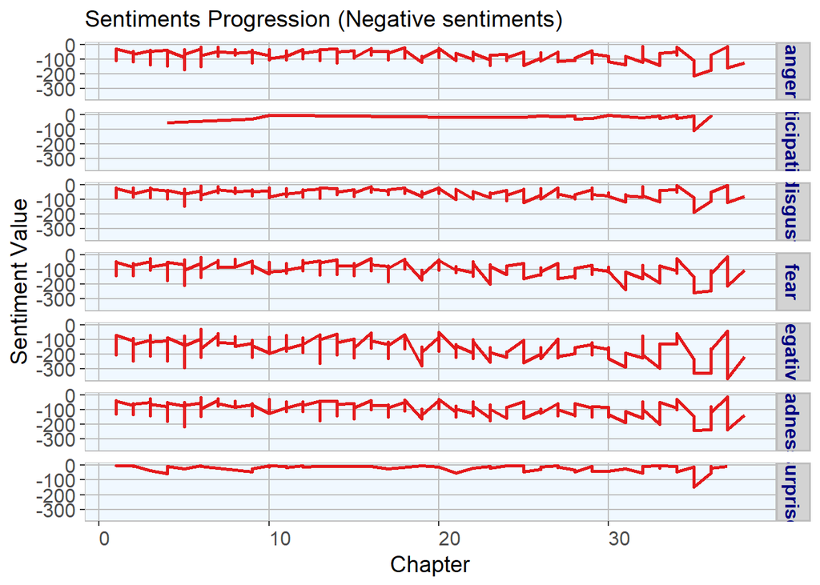

```r
# plot sentiment df
harrypotter_sentiment%>%
  filter(count<0)%>%
  ggplot( aes(x = Chapter, y = count)) +
  geom_line(size = 1, color = brewer.pal(3, "Set1")[1]) +
  facet_grid(sentiment~.) +
  uniform_ggplot_theme() +
  theme(
    axis.text.x = element_text(angle = 0, vjust = 0, hjust = 0),
    legend.position = "none") +
  labs(x = "Chapter", y = "Sentiment Value",
       title = "Sentiments Progression (Negative sentiments)")
```

### Q9. How does sentiment changes over time for each book? Which book has the highest variation?

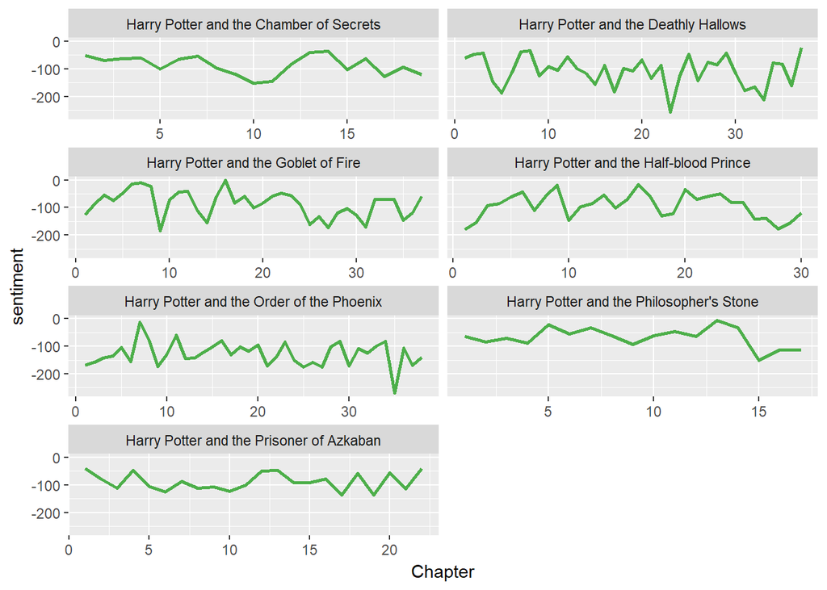

```r
hp_df<- harrypotter_clean_tokens%>%
  inner_join(get_sentiments("bing"), by = "word") %>% # join sentiment
  count(Title, Chapter, sentiment, sort = TRUE)%>% # count sentiment
  spread(sentiment, n, fill = 0) %>%
  mutate(sentiment = positive - negative)

ggplot(hp_df, aes(Chapter, sentiment, fill = Title))+
  geom_line(size = 1, color = brewer.pal(3, "Set1")[3]) +
  facet_wrap(~Title, ncol = 2, scales = "free_x")
```

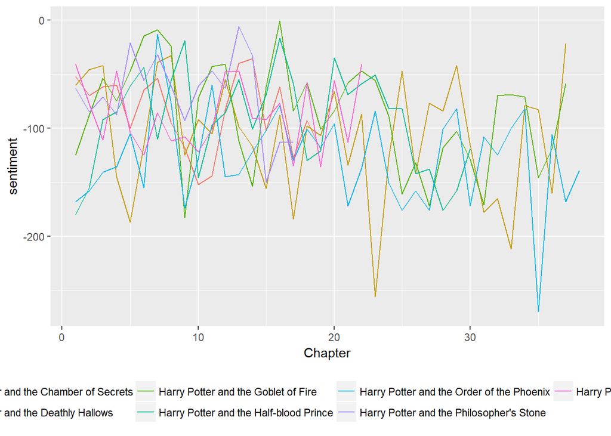

```r
ggplot(hp_df, aes(Chapter, sentiment, colour = Title))+
  geom_line()+
  theme(
    legend.position ="bottom")
```

```r
# looks like Harry Potter and the Deathly Hallows has the highest sentimental variation
```

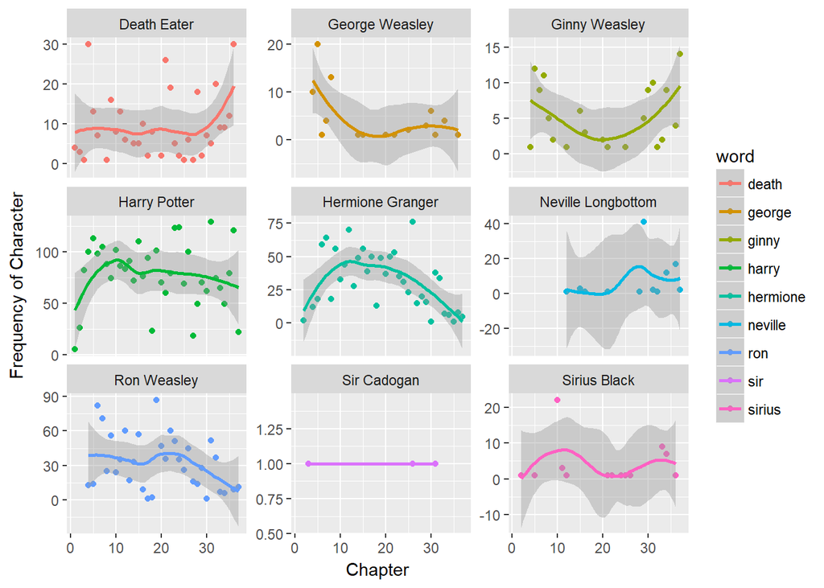

```r
top_n_characters <- harrypotter_clean_tokens %>%
  mutate(id = R.utils::capitalize(word)) %>%
  inner_join(harrypotter_characters, by =c(id = "FirstName") ) %>%
  count(FullName,word,sort= TRUE) %>%
  top_n(9)


harrypotter_clean_tokens %>%
  # get the last book of HP
  filter(Title=='Harry Potter and the Deathly Hallows')%>%
  mutate(id = R.utils::capitalize(word)) %>% # create uniq id
  # get all characters by first name
  inner_join(harrypotter_characters, by = c(id = "FirstName")) %>%
  count( Chapter, FullName,word, sort = TRUE) %>%
  filter(word %in% as.vector(top_n_characters$word))%>%
  #plot the graph
  ggplot(aes(Chapter, n, color=word)) +
  geom_point() +
  geom_smooth() +
  facet_wrap(~ FullName, scales = "free_y") +
  ylab("Frequency of Character")
```

### Q11. What are the top 6 topics discussed in harry potter

```r
# include only words and  not characters
hp_topic_model_df <- harrypotter_clean_tokens %>%
  mutate(id = R.utils::capitalize(word)) %>%
  # Remove Characters by 1st name
  anti_join(harrypotter_characters, by =c(id = "FirstName") ) %>%
  # Remove Characters by last name
  anti_join(harrypotter_characters, by =c(id = "LastName") ) %>%
  unite(document, Title, Chapter) %>%
  # count token
  count(document,word,sort= TRUE)  %>%
  filter(n > 15)

chapters_dtm <- hp_topic_model_df %>%
  cast_dtm(document, word, n)

chapters_lda <- LDA(chapters_dtm, k = 6, control = list(seed = 4564))

chapter_topics <- tidy(chapters_lda, matrix = "beta")
head(chapter_topics)
```

```
## # A tibble: 6 x 3
##   topic      term          beta
##   <int>     <chr>         <dbl>
## 1     1 professor  4.142147e-01
## 2     2 professor  3.179345e-25
## 3     3 professor  3.940360e-11
## 4     4 professor 7.487264e-186
## 5     5 professor  1.187918e-09
## 6     6 professor  2.747913e-04
```

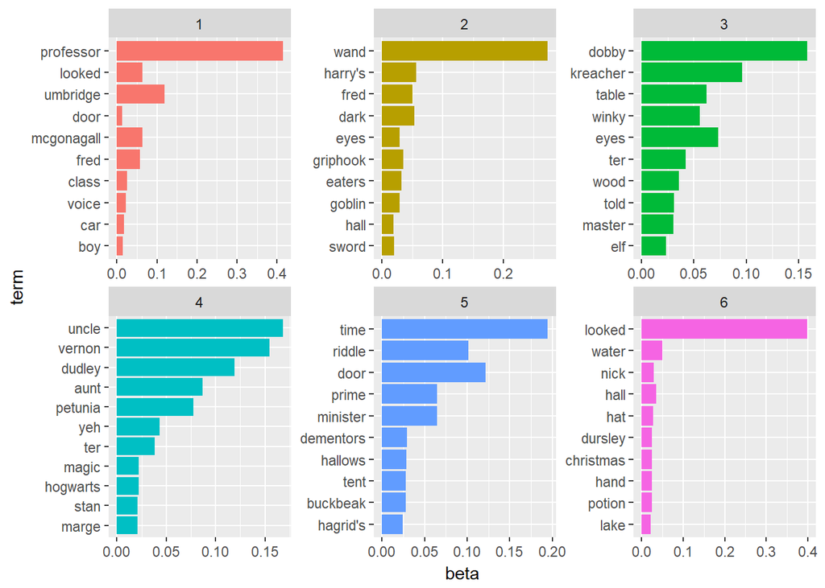

```r
chapter_topics %>%
  group_by(topic) %>%
  top_n(10, beta) %>% #get only top 10 terms
  ungroup() %>%
  arrange(topic, -beta) %>%
  mutate(term = reorder(term, beta)) %>%
  # generate graph
  ggplot(aes(term, beta, fill = factor(topic))) +
  geom_col(show.legend = FALSE) +
  facet_wrap(~ topic, scales = "free") +
  coord_flip()
```

```r
# it is dificult to decode all types of  topics potrayed by the author, because of low LDA k value. Increasing k slows down runtime
```

### Q12. How Does the 6 topics discussed varry from each series of Harry Potter

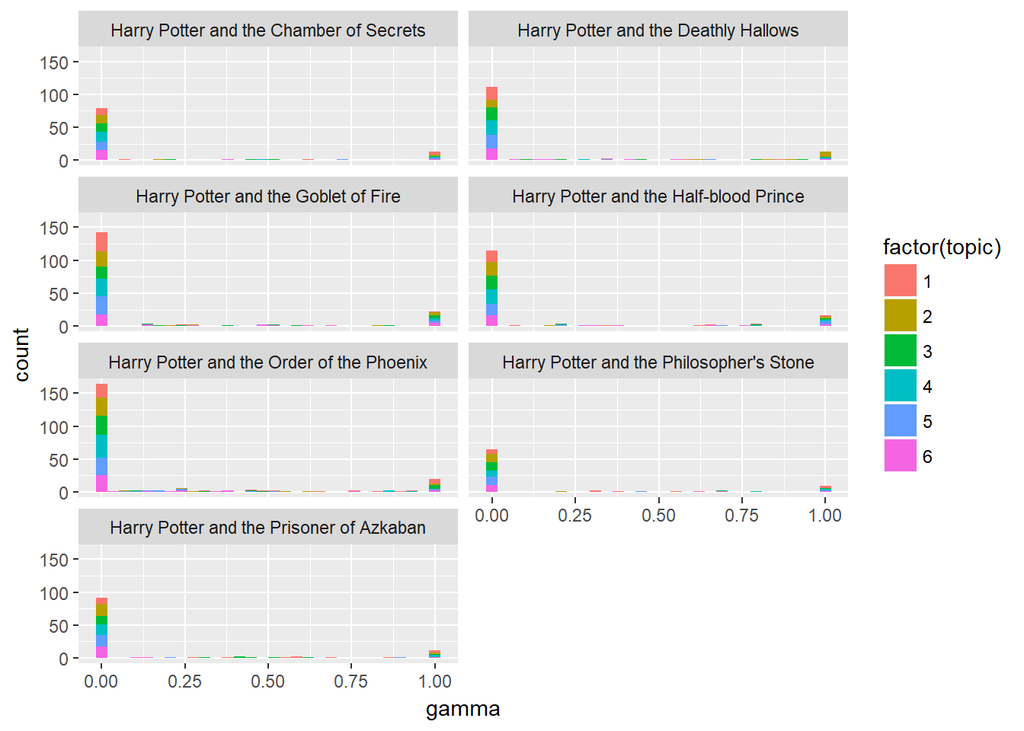

```r
tidy(chapters_lda, matrix = "gamma") %>%
  # extract book title
  separate(document, c("title", "chapter"), sep = "_", convert = TRUE)%>%
  ggplot( aes(gamma, fill = factor(topic))) +
  geom_histogram() +
  facet_wrap(~title, nrow = 6)
```

# Acknowledgments

Question Template from http://tidytextmining.com